# Attention Markets in Religious Digital Media

# 3 Data and Methods

## 3.1 The DigiKat Database

This study draws on the DigiKat database, a comprehensive collection of Croatian Catholic digital content developed as part of a three year research project (2025 to 2027). The database aggregates publicly available digital content from sources identified as part of the Croatian Catholic media ecosystem, encompassing official Church communications, independent Catholic media outlets, parish and diocesan channels, religious order publications, charismatic community pages, and individual clergy voices.

The analytical corpus comprises 372,944 posts published between siječanj 01, 2021 and prosinac 31, 2024 across 8 platform categories. Web content constitutes the largest volume, followed by Facebook, Instagram, YouTube, Twitter, forums, Reddit, and user comments on Catholic portals. The database encompasses 9,896 unique sources.

## 3.2 Data Collection

Data collection employed multiple complementary methods adapted to platform specific technical constraints. Web content was gathered through automated scraping of identified Catholic portals. Facebook and Instagram data were obtained through CrowdTangle. YouTube data were collected via the YouTube Data API. Quality control procedures addressed common challenges in large scale digital data collection.

## 3.3 Actor Classification

To analyze attention distribution across different types of Catholic communicators, we developed a hierarchical classification system assigning each source to one of ten actor categories. The resulting ten categories comprise: Institutional Official, Diocesan, Independent Media, Religious Orders, Charismatic Communities, Individual Priests, Youth Organizations, Academic, Lay Influencers, and Other.

## 3.4 Analytical Approach

The analysis proceeds through four complementary dimensions. For market structure and concentration, we use Gini coefficients, Lorenz curves, and concentration ratios. For the institutional attention gap, we employ the Wilcoxon rank sum test. For emotional attention capture, we examine Facebook reaction distributions using Kruskal Wallis tests. For temporal dynamics, we map posting activity onto the Catholic liturgical calendar.

# 4 Results

## 4.1 Market Structure and Concentration

Table 1: Distribution of posts and engagement by platform

Distribution of posts and engagement by platform

| Platform | Posts | Interactions | Sources | Mean Int. | Volume % | Engagement % | Efficiency |
| --- | --- | --- | --- | --- | --- | --- | --- |
| web | 295,860 | 32,256,123 | 2,738 | 109.0 | 79.3% | 79.1% | 1.00 |
| youtube | 38,267 | 4,946,542 | 2,838 | 133.1 | 10.3% | 12.1% | 1.18 |
| facebook | 24,269 | 3,268,408 | 1,510 | 134.7 | 6.5% | 8.0% | 1.23 |
| forum | 4,361 | 0 | 7 | NaN | 1.2% | 0.0% | 0.00 |
| reddit | 3,857 | 0 | 1,319 | NaN | 1.0% | 0.0% | 0.00 |
| twitter | 3,211 | 28,532 | 1,536 | 8.9 | 0.9% | 0.1% | 0.08 |
| comment | 1,989 | 0 | 23 | NaN | 0.5% | 0.0% | 0.00 |
| instagram | 1,130 | 299,344 | 54 | 264.9 | 0.3% | 0.7% | 2.42 |

The efficiency index, calculated as the ratio of engagement share to volume share, reveals substantial variation in platform effectiveness. Values above 1.0 indicate platforms generating more engagement than their content volume would predict.

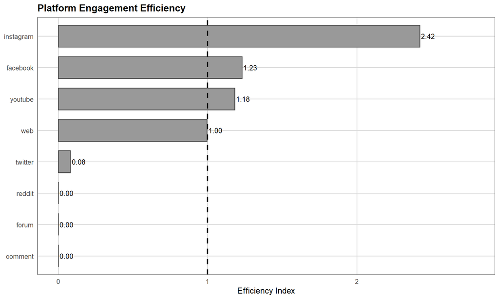

Figure 1: Platform engagement efficiency. The efficiency index represents the ratio of engagement share to volume share, with values above 1.0 (dashed line) indicating above average performance.

### 4.1.1 Concentration Measures

Concentration measures test Hypotheses 1 and 2. The Gini coefficient is 0.980, indicating extreme inequality in attention distribution. For comparison, this substantially exceeds typical income inequality measures in most developed countries. The power law regression yields R squared = 0.912, strongly supporting Hypothesis 1 regarding power law distribution.

Concentration ratios show that the top 10 sources capture 44.6% of total engagement, the top 20 sources capture 56.5%, and the top 10 percent of all sources (990 sources) capture 98.3% of total engagement.

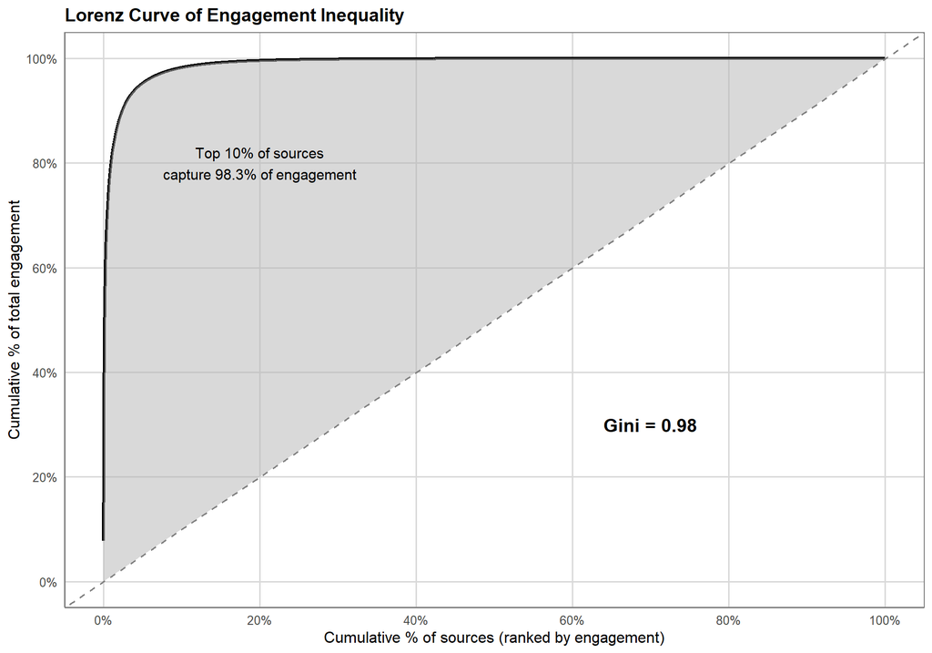

Figure 2: Lorenz curve of engagement inequality. The shaded area between the curve and the equality diagonal represents the degree of concentration.

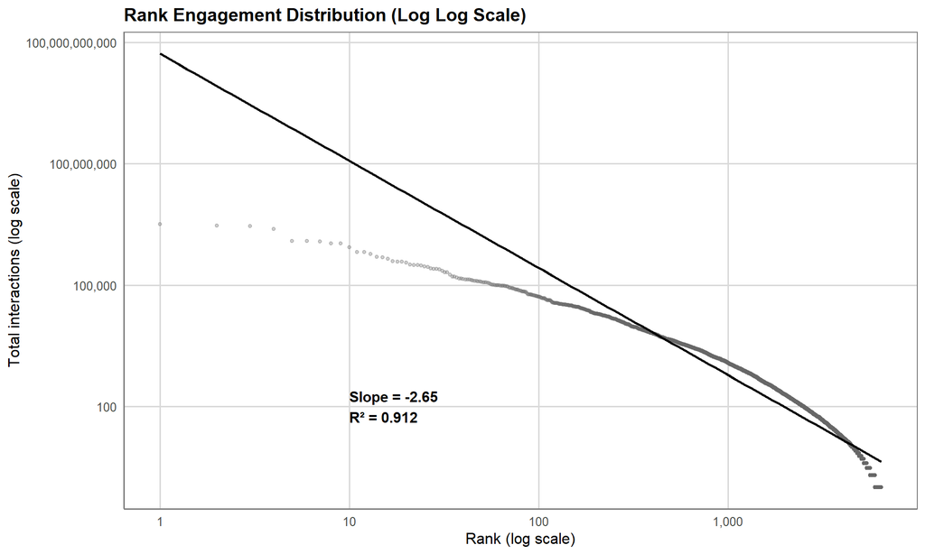

## 4.2 Actor Stratification and Institutional Gap

Table 2: Content and engagement by actor type

Content and engagement by actor type

| Actor Type | Sources | Posts | Interactions | Mean Int. | Posts % | Engagement % | Efficiency |
| --- | --- | --- | --- | --- | --- | --- | --- |
| Other | 9,396 | 275,765 | 30,383,155 | 114.8 | 73.9% | 74.5% | 1.01 |
| Independent Media | 15 | 20,113 | 4,971,266 | 247.2 | 5.4% | 12.2% | 2.26 |
| Institutional Official | 142 | 49,339 | 3,141,703 | 63.7 | 13.2% | 7.7% | 0.58 |
| Lay Influencers | 175 | 13,500 | 1,726,046 | 129.9 | 3.6% | 4.2% | 1.17 |
| Diocesan | 89 | 11,278 | 453,441 | 40.2 | 3.0% | 1.1% | 0.37 |
| Charismatic Communities | 13 | 551 | 68,683 | 130.3 | 0.1% | 0.2% | 1.14 |
| Religious Orders | 36 | 1,678 | 37,113 | 22.4 | 0.4% | 0.1% | 0.20 |
| Academic | 12 | 473 | 8,842 | 18.7 | 0.1% | 0.0% | 0.17 |
| Youth Organizations | 7 | 111 | 4,606 | 41.5 | 0.0% | 0.0% | 0.38 |
| Individual Priests | 15 | 136 | 4,094 | 30.1 | 0.0% | 0.0% | 0.28 |

### 4.2.1 Statistical Tests

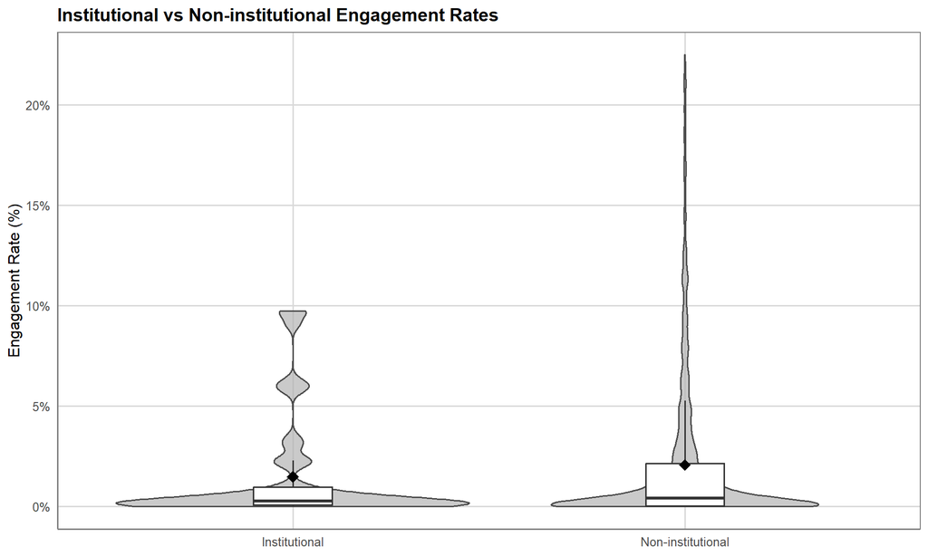

Figure 4: Engagement rate distributions comparing institutional and non-institutional actors. Black diamonds indicate means.

## 4.3 Emotional Attention Capture

Table 3: Emotional profiles by actor type (mean reaction share)

Emotional profiles by actor type (mean reaction share)

| Actor Type | Posts | LOVE | WOW | HAHA | SAD | ANGRY |
| --- | --- | --- | --- | --- | --- | --- |
| Academic | 1 | 100.0% | 0.0% | 0.0% | 0.0% | 0.0% |
| Lay Influencers | 22 | 95.3% | 0.0% | 0.2% | 4.5% | 0.0% |
| Diocesan | 8 | 75.1% | 0.0% | 0.0% | 24.9% | 0.0% |
| Independent Media | 32 | 62.8% | 2.0% | 9.2% | 20.5% | 5.5% |
| Other | 136 | 43.2% | 2.7% | 25.9% | 12.3% | 15.9% |
| Institutional Official | 2 | 0.0% | 50.0% | 16.7% | 0.0% | 33.3% |

LOVE and ANGRY reaction shares differ significantly across actor types (Kruskal Wallis chi squared = 31 for LOVE, *p* < 0.001; chi squared = 26.3 for ANGRY, *p* < 0.001), confirming Hypothesis 4 regarding emotional differentiation.

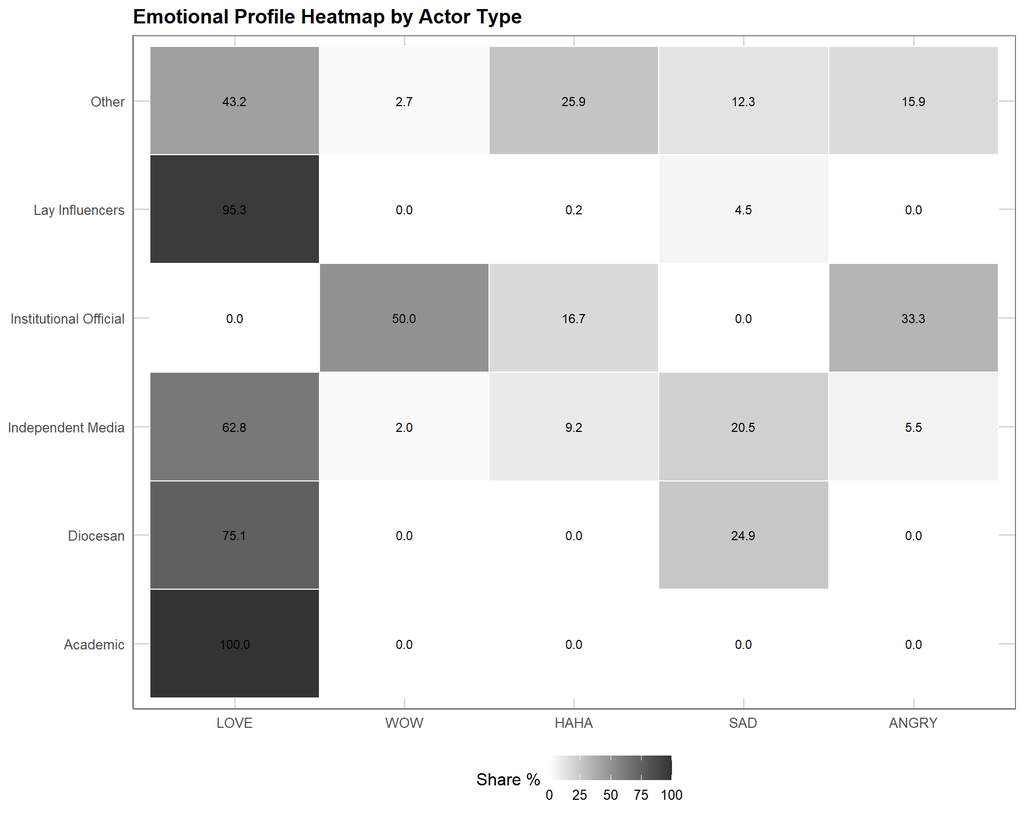

Figure 5: Heatmap of emotional profiles by actor type. Darker colors indicate higher shares.

## 4.4 Temporal Dynamics

Table 4: Activity by liturgical season

Activity by liturgical season

| Season | Posts | Interactions | Mean Int. | Days | Posts/Day | Int./Day | Effect vs Baseline |
| --- | --- | --- | --- | --- | --- | --- | --- |
| Advent | 38,711 | 3,308,225 | 87.1 | 99 | 391 | 33416 | +32.6% |
| Christmas | 24,227 | 3,295,516 | 141.6 | 73 | 332 | 45144 | +12.5% |
| Lent | 34,746 | 4,020,204 | 118.5 | 138 | 252 | 29132 | -14.6% |
| Easter | 33,741 | 4,238,255 | 130.0 | 141 | 239 | 30059 | -18.9% |
| Ordinary Time | 241,519 | 25,936,749 | 110.9 | 819 | 295 | 31669 | +0.0% |

A one sample t test confirms that feast days generate significantly elevated posting activity compared to baseline (*t* = 4.9, df = 34, *p* < 0.001), with a mean effect size of 32.0% above baseline.

## 4.5 Hypothesis Testing Summary

Table 5: Summary of hypothesis testing results

Summary of hypothesis testing results

[output not shown]

# 5 Discussion

The findings reveal that the Croatian Catholic digital space exhibits attention inequality comparable to or exceeding patterns documented in commercial media ecosystems. The Gini coefficient of 0.980 substantially exceeds thresholds typically associated with high concentration. These results confirm Hypothesis 1 and align with theoretical predictions about winner takes all dynamics in digital environments.

# 6 Conclusion

This study provides the first systematic mapping of a national Catholic digital media ecosystem, analyzing over 372,944 posts across multiple platforms to examine attention distribution, actor stratification, emotional dynamics, and temporal patterns in Croatian Catholic digital communication.

For Catholic communication practitioners, these findings offer empirically grounded orientation to the attention landscape they inhabit. Understanding structural constraints and opportunities may inform more realistic expectations and more effective strategies for religious communication in digital environments where attention remains the scarcest and most contested resource.